# PA1_template

Rezyananya

14 September 2017

# Let’s first read the data

```
FootStep <- read.csv(file="C:/Users/Priyanka/Documents/Reproducible/activity.csv",header = T,sep = ",",stringsAsFactors = FALSE)
```

# compute the date

[output not shown]

## Calculate total number of steps taken each day

```
  MeanTotal <- FootStep %>% group_by(date) %>%
  summarize(TotalSteps = sum(steps,na.rm = T),
  MeanSteps = mean(steps,na.rm = T))
```

## Histogram of the total number of steps taken each day

```
png(filename = 'hist1.png', width = 480, height = 480, units='px')
  with(MeanTotal, hist(TotalSteps, xlab = 'Total Steps per day', main = 'Frequency', col = 'red'))
  dev.off
Graph is showing the hightest steps taken during the period (10000 - 15000).
```

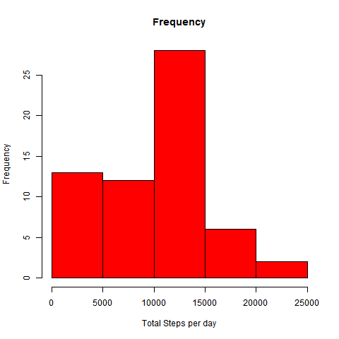

alt text

# Calculate and report the mean and median of the total number of steps taken per day

[output not shown]

# What is the average daily activity pattern?

```
  AverageDailyPattern <- FootStep %>% group_by(interval) %>%
    summarize(MeanSteps = mean(steps,na.rm = T))
```

# 1.make time series plot (i.e. type = “l”) of the 5-minute interval (x-axis) and the average number of steps taken,averaged across all days (y-axis).

```
  #png graph
  png(filename = 'timeseries.png', width = 480, height = 480, units='px')
  plot(AverageDailyPattern, xlab = 'interval', ylab = 'Average number of steps taken', type   = 'l')

  important to off
  dev.off()
```

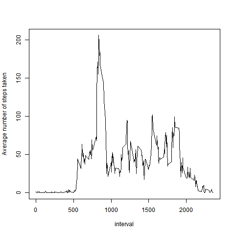

alt text

# Which 5-minute interval, on average across all the days in the dataset,contains the maximum number of steps?

Ans: Maxium number of steps taken between the interval (500-1000).

# 1.Calculate and report the total number of missing values in the dataset(i.e the total number of rows with NAs)

[output not shown]

# As we can see we don’t have any missing values here now.

[output not shown]

# Create a new dataset (totalNA) that is equal to the original dataset but with the missing data filled in.

[output not shown]

# Graph

```
png(filename = 'hist2.png', width = 480, height = 480, units='px')
with(MeanTotal2, hist(TotalSteps, xlab = 'Total Steps per day', main = 'Frequency', col = 'blue'))

important to off
dev.off()
```

Conclusion:Graph is showing the hightest steps taken during the period (10000 - 15000) again with new datasetbut this time with a littel increase in the frequency as compare to previous data.Yes there is little difference in their mean and median.

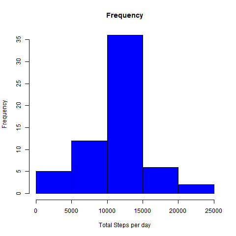

alt text

# Difference of two datasets

[output not shown]

# Are there differences in activity patterns between weekdays and weekends?

```
  totalNA$day<- ifelse(weekdays(totalNA$date) %in% c("Saturday", "Sunday"), "weekend",   "weekday")

  Weekend <- filter(totalNA, day == "weekend")
  Weekday <- filter(totalNA, day == "weekday")
  Weekend <- Weekend %>% group_by(interval) %>%
  summarize(MeanSteps = mean(steps))
  Weekend$day <- "weekend"

  Weekday <- Weekday %>% group_by(interval) %>%
  summarize(MeanSteps = mean(steps))
  Weekday$day <- "weekday"

  ActivityPattern <- rbind(Weekend, Weekday)
  ActivityPattern$day <- as.factor(ActivityPattern$day)
  ActivityPattern$day <- relevel(ActivityPattern$day, "weekend")
```

# Make a panel plot containing a time series plot (i.e. type = “l”) of the 5-minute interval (x-axis) and the average number of steps taken, averaged across all weekday days or weekend days (y-axis).

```
  library(ggplot2)
  png(filename = 'timeseries2.png', width = 480, height = 480, units='px')

  g <- ggplot(ActivityPattern, aes (interval, MeanSteps))
  g + geom_line() + facet_grid (day~.)+ labs(y = "Average number of steps taken") + labs(x   = "Interval")
  important to off
  dev.off()
```

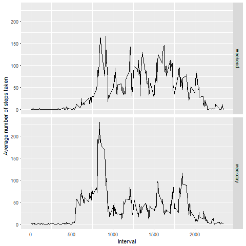

alt text